# Choose your own splitting criteria

Follow along: http://bit.ly/forestr

## Background

- The random forest (Breiman 2001) is an ensemble method implemented in `R` (R Core Team 2015) in the `randomForest` package (Liaw and Wiener 2002).
- General framework for building a model by combining trees, however implementation is very specific - Gini splitting criteria
- The `forestr` package (Kaplan 2015) implements the random forest methodology with a choice of splitting criteria, namely:
  - Gini,
  - Information,
  - One-sided Extremes, and
  - One-sided Purity.

## One-sided splitting methods

- One-sided extremes and one-sided purity introduced by Buja and Lee (2001) as a means to "identify pure or extreme buckets" in the data
- Perpendicular to the conventional splitting methods that attempt to perform equally well on both sides of the split
- The one-sided splitting methods instead search for "interesting subsets of data as opposed to modelling all of the data equally well." (Buja and Lee 2001, 1)

[output not shown]

## Higgs Example

- Monte Carlo simulations to resemble properties measured by particle detectors in an accelerator to detect the Higgs particle (Baldi, Sadowski, and Whiteson 2014)
- 21 features that are kinematic properties measured by the particle detectors in the accelerator
- Attempt to predict the detection of the Higgs particle using a random forest with different splitting mechanisms for some degrees of unbalancedness
- Created small subset, 200 observations, with desired unbalancedness level (25%)

## Features

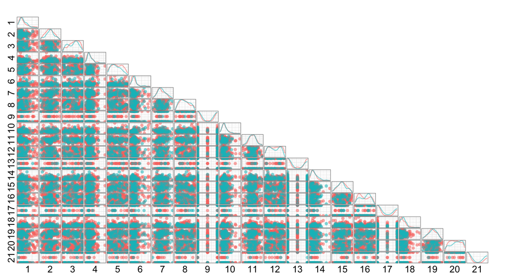

## Features (Cont'd)

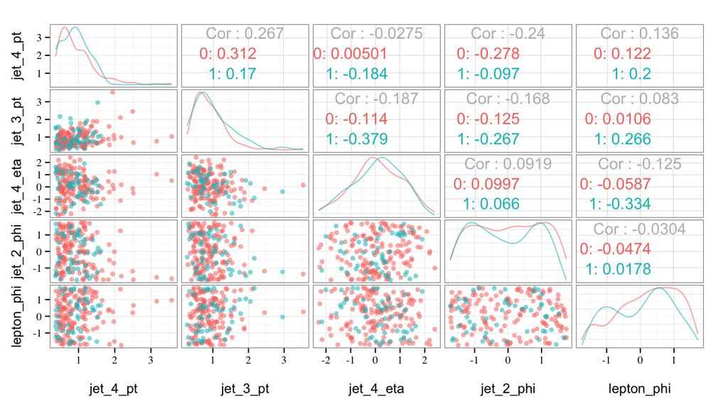

## Fitting

```r
#train forests
rf_gini_25 <- forestr(class ~ ., data = higgs_25 %>% select(-starts_with("m_")))
rf_info_25 <- forestr(class ~ ., data = higgs_25 %>% select(-starts_with("m_")),
                      parms = list(split = "information"))
rf_extr_25 <- forestr(class ~ ., data = higgs_25 %>% select(-starts_with("m_")),
                  method = "extremes", parm = list(classOfInterest = "1"))
rf_puri_25 <- forestr(class ~ ., data = higgs_25 %>% select(-starts_with("m_")),
                      method = "purity")

#test four forests
rf_gini.pred_25 <- predict(rf_gini_25, test_higgs_25 %>% select(-starts_with("m_")))
rf_info.pred_25 <- predict(rf_info_25, test_higgs_25 %>% select(-starts_with("m_")))
rf_extr.pred_25 <- predict(rf_extr_25, test_higgs_25 %>% select(-starts_with("m_")))
rf_puri.pred_25 <- predict(rf_puri_25, test_higgs_25 %>% select(-starts_with("m_")))
```

## Results

#### Out-of-bag

|  | Gini | Information | Extremes | Purity |
| --- | --- | --- | --- | --- |
| OOB Error | 0.25 | 0.25 | 0.315 | 0.315 |
| Class of Interest Error | 1.00 | 1.00 | 0.880 | 0.940 |

#### Test predictions

|  | Gini | Information | Extremes | Purity |
| --- | --- | --- | --- | --- |
| Overall Error | 0.25 | 0.25 | 0.345 | 0.32 |
| Class of Interest Error | 1.00 | 1.00 | 0.900 | 0.90 |

## Importance

```r
rf_gini.imp_25 <- importance(rf_gini_25)
rf_info.imp_25 <- importance(rf_info_25)
rf_extr.imp_25 <- importance(rf_extr_25)
rf_puri.imp_25 <- importance(rf_puri_25)
```

## Importance Cont'd

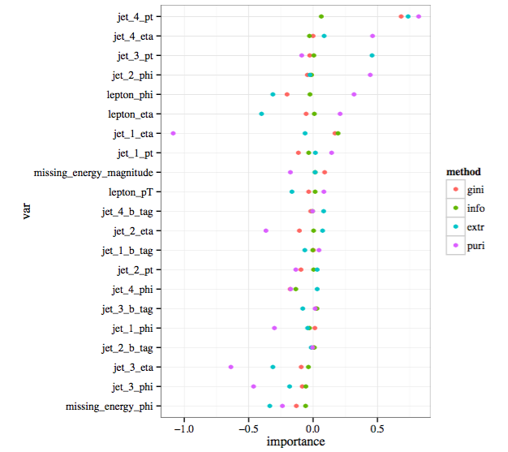

## Implementation

- Written in `R`
- Wraps random forest methodology around modified `rpart` stubs

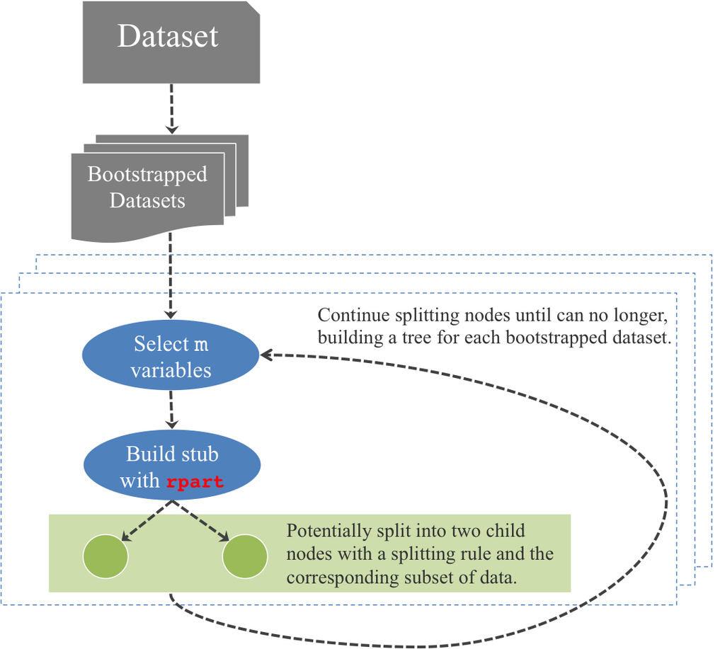

## Remarks

- Written completely in `R` \(\Rightarrow\) slow
  - Next step would be to rewrite the inner workhorse functions in `C++` to help with a speedup
  - Alternative could be to alter the `randomForest` package to include alternative splitting mechanisms, but this package is written in `Fortran`, and so would need some updating first

## Lessons learned

[figure not shown]

## Lessons learned

- Writing an `R` package is easy with `devtools`
- Writing generalized code is hard
  - Writing generalized code without bugs is harder
  - Writing generalized code that isn't slow is even harder
  - Editing other peoples' code is **hardest**
  - Especially in a language not fluent in (`Fortran` and `C`)
- Open source community is great
  - Communication with author of `itree` helped to find the issues
- S3 classes are really neat and easy

## Thanks!

Questions?

ajkaplan@iastate.edu

## Appendix

## Installation

`forestr` and and accompanying dependency package `rpart` can be installed from GitHub in `R` with `devtools` (Wickham and Chang 2015).

```r
library(devtools)
install_github("andeek/rpart")
install_github("andeek/forestr")
```

## References

Baldi, P, P Sadowski, and D Whiteson. 2014. “Searching for Exotic Particles in High-Energy Physics with Deep Learning.” *Nature Communications* 5. Nature Publishing Group.

Breiman, Leo. 2001. “Random Forests.” *Machine Learning* 45 (1). Springer: 5–32.

Buja, Andreas, and Yung-Seop Lee. 2001. “Data Mining Criteria for Tree-Based Regression and Classification.” In *Proceedings of the Seventh ACM SIGKDD International Conference on Knowledge Discovery and Data Mining*, 27–36. ACM.

Kaplan, Andee. 2015. *Forestr: Random Forests with a User Created Splitting Criteria.* https://github.com/andeek/forestr.

Liaw, Andy, and Matthew Wiener. 2002. “Classification and Regression by RandomForest.” *R News* 2 (3): 18–22. http://CRAN.R-project.org/doc/Rnews/.

R Core Team. 2015. *R: A Language and Environment for Statistical Computing*. Vienna, Austria: R Foundation for Statistical Computing. http://www.R-project.org/.

Wickham, Hadley, and Winston Chang. 2015. *Devtools: Tools to Make Developing R Packages Easier*. http://CRAN.R-project.org/package=devtools.